# 2 Joint modelling

## 1 Learning Objectives

**Note**

By the end of this lecture, you should be able to:

- Understand **why joint models are needed** when time-dependent covariates are **internal**
- Distinguish between **extended Cox models** and **joint models**
- Describe the two components of a **joint model**:
  - a **longitudinal submodel** (e.g. eGFR over time)
  - a **time-to-event submodel** (e.g. graft failure)
- Explain how the **longitudinal process is linked to the survival process**
- Interpret key parameters from a **joint model**
- Recognise situations where joint models provide **less biased and more realistic inference**

## 2 Why Do We Need Joint Models?

In the **extended Cox model**, we allowed covariates to change over time. However, this approach relies on a key assumption:

- The time-varying covariate is **external**
- Its evolution is **not influenced by the underlying event process**

This assumption is often unrealistic in medical and public health studies.

**NoteThe Problem of Internal Time-Dependent Covariates**

A **time-dependent covariate is internal** if:

- It is affected by the same disease process that leads to the event
- It both **predicts** the event and is **influenced by** the event process

A common example in transplantation studies is **eGFR**:

- Declining eGFR increases the risk of graft failure
- At the same time, eGFR declines **because the graft is failing**

**Warning**

When a time-dependent covariate is internal,  
the extended Cox model may produce **biased estimates**.

## 3 Why the Extended Cox Model Is Not Enough

In the extended Cox model:

- The longitudinal process (e.g. eGFR) is treated as **error-free**
- Measurement error in repeated biomarker values is ignored
- The feedback between the biomarker and the event is not modelled

As a result:

- The estimated effect of the biomarker may be biased
- Standard errors may be underestimated
- Interpretation can be misleading

🫘 **Graft function declines**  
⬇️  
🧪 **More clinical tests**  
⬇️  
🧫 **Lower eGFR measurements**  
⬇️  
⚠️ **Patient appears riskier**  
⬇️  
📈 **Effect is exaggerated**

## 4 Joint Models

**Joint models** address these limitations by:

- Modelling the **longitudinal trajectory** (e.g. eGFR over time)
- Modelling the **time-to-event outcome** (e.g. graft failure)
- Explicitly **linking the two processes**

This allows us to:

- Account for **measurement error** in the biomarker
- Handle **internal time-dependent covariates**
- Obtain more realistic estimates of risk

## 5 Visual demonestraion of longitudinal process (eGFR) and survival process (time to graft lost)

**Figure 1: Individual and average eGFR trajectories after kidney transplantation**

The left panel shows **individual longitudinal eGFR trajectories** for a subset of transplant recipients, illustrating substantial **between-patient heterogeneity** in both baseline kidney function and the rate of decline over time. Some patients experience relatively stable eGFR, while others show rapid deterioration, highlighting that kidney function evolves differently across individuals.

**Show R code**

```r
library(ggplot2)
library(dplyr)
```

**Show R code**

```r
library(gridExtra)
```

**Show R code**

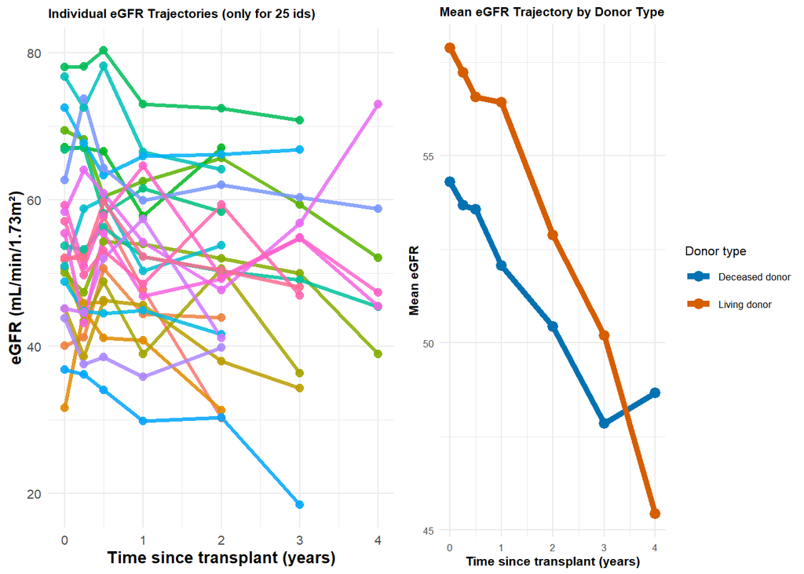

```r
dat_long<-read.csv("https://raw.githubusercontent.com/NicoleDeLaMata/AdvancedSurvival/refs/heads/Data/egfr_joint_data.csv")
# sample 25 patients for visual clarity
set.seed(20251113)
ids_sample <- sample(unique(dat_long$id), 25)

p_traj <- dat_long %>%
  filter(id %in% ids_sample) %>%
  ggplot(aes(x = time, y = egfr, group = id, colour = factor(id))) +
  geom_line(size = 1.2, alpha = 0.85) +
  geom_point(size = 2.2, alpha = 0.9) +
  scale_colour_discrete(guide = "none") +
  labs(
    x = "Time since transplant (years)",
    y = "eGFR (mL/min/1.73m²)",
    title = "Individual eGFR Trajectories (only for 25 ids)"
  ) +
  theme_minimal(base_size = 10) +
  theme(
    plot.title = element_text(face = "bold", size = 8),
    axis.title = element_text(face = "bold")
  )




p_traj_by_donor <- dat_long %>%
  group_by(donor_type, time) %>%
  summarise(mean_egfr = mean(egfr), .groups = "drop") %>%
  ggplot(aes(x = time, y = mean_egfr,
             colour = factor(donor_type),
             group = donor_type)) +
  geom_line(size = 1.8) +
  geom_point(size = 3) +
  scale_colour_manual(
    values = c("0" = "#0072B2",    # deceased = blue
               "1" = "#D55E00"),   # living = red
    labels = c("0" = "Deceased donor",
               "1" = "Living donor")
  ) +
  labs(
    x = "Time since transplant (years)",
    y = "Mean eGFR",
    colour = "Donor type",
    title = "Mean eGFR Trajectory by Donor Type"
  ) +
  theme_minimal(base_size = 8) +
  theme(
    plot.title = element_text(face = "bold", size = 8),
    axis.title = element_text(face = "bold")
  )




# Arrange side by side
grid.arrange(
  p_traj,
  p_traj_by_donor,
  ncol = 2
)
```

**Figure 2: Kaplan–Meier curves for time to graft failure**

The **left panel** shows the **overall Kaplan–Meier curve** for time to graft failure, summarising graft survival for all transplant recipients combined. The stepwise nature of the curve reflects the occurrence of graft failure events over follow-up, while the shaded area represents the **95% confidence interval**.

**Show R code**

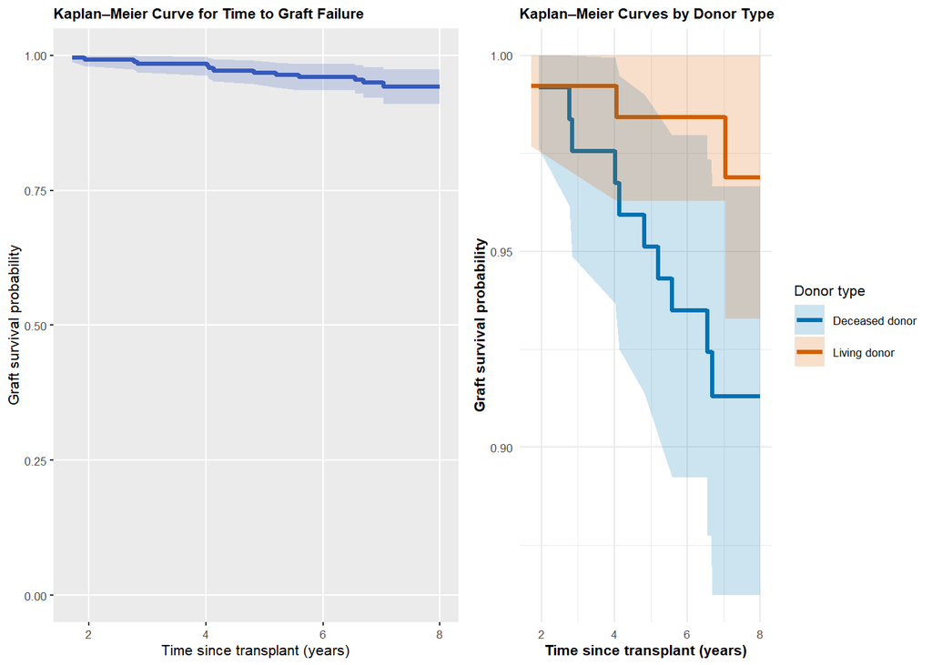

```r
library(survival)
library(broom)

dat_baseline<-read.csv("https://raw.githubusercontent.com/NicoleDeLaMata/AdvancedSurvival/refs/heads/Data/egfr_wide_data.csv")


# overall KM
surv_obj <- Surv(time = dat_baseline$time, event = dat_baseline$status)

fit_km <- survfit(surv_obj ~ 1)

km_df <- data.frame(
  time  = fit_km$time,
  surv  = fit_km$surv,
  lower = fit_km$lower,
  upper = fit_km$upper
)

KM1<-ggplot(km_df, aes(x = time, y = surv)) +
  geom_step(linewidth = 1.2, colour = "#365abd") +
  geom_ribbon(aes(ymin = lower, ymax = upper),
              alpha = 0.2,
              fill = "#365abd") +
  labs(
    title = "Kaplan–Meier Curve for Time to Graft Failure",
    x = "Time since transplant (years)",
    y = "Graft survival probability"
  ) +
  coord_cartesian(ylim = c(0, 1)) +
  theme_grey(base_size = 8) +
  theme(
    plot.title = element_text(face = "bold", size = 8),
    panel.grid.minor = element_blank()
  )



#KM curve by donor type
fit_km_donor <- survfit(Surv(time, status) ~ donor_type, data = dat_baseline)

km_df <- tidy(fit_km_donor)

p_km <- km_df %>%
  mutate(
    donor_type = factor(strata,
                        labels = c("Deceased donor", "Living donor"))
  ) %>%
  ggplot(aes(x = time, y = estimate,
             colour = donor_type, fill = donor_type)) +
  geom_step(size = 1.2) +
  geom_ribbon(aes(ymin = conf.low, ymax = conf.high),
              alpha = 0.20, colour = NA) +
  scale_colour_manual(
    values = c("Deceased donor" = "#0072B2",
               "Living donor"   = "#D55E00")
  ) +
  scale_fill_manual(
    values = c("Deceased donor" = "#0072B2",
               "Living donor"   = "#D55E00")
  ) +
  labs(
    x = "Time since transplant (years)",
    y = "Graft survival probability",
    colour = "Donor type",
    fill = "Donor type",
    title = "Kaplan–Meier Curves by Donor Type"
  ) +
  theme_minimal(base_size = 8) +
  theme(
    plot.title = element_text(face = "bold", size = 8),
    axis.title = element_text(face = "bold")
  )





# Arrange side by side
grid.arrange(
  KM1,
  p_km,
  ncol = 2
)
```

Importantly, these plots illustrate that **eGFR is a time-varying, patient-specific process** that is closely linked to graft failure risk. Treating eGFR as a fixed baseline covariate or updating it naively in an extended Cox model may be inappropriate, as changes in eGFR can be driven by the underlying disease process itself. This motivates the use of **joint models**, which explicitly model the longitudinal eGFR process together with the time-to-event outcome.

**Note**

Joint models provide a unified framework for analysing  
**longitudinal measurements** and **time-to-event outcomes** together.

- They allow eGFR to be an internal time-varying covariate
- They account for correlations between eGFR and risk of graft failure
- They handle varying measurement times
- They reduce bias caused by feedback loops
- They improve prediction of graft loss

## 6 Joint Model Specification (Linear Mixed Model + Cox Model)

Here, we focus on a **joint model combining a linear mixed-effects model and a Cox proportional hazards model**.  
More generally, the joint modelling framework is highly flexible and can be extended to:

- a wide range of **longitudinal models**, including **linear and non-linear mixed models**, and
- different types of **survival models**, including **parametric** and **semi-parametric** models.

The key idea is that the longitudinal and survival processes are modelled **simultaneously** and linked through shared subject-specific components.

### 6.1 Longitudinal Submodel (Linear Mixed Effects Model)

Let $y_i(t)$ be the observed biomarker value (e.g. eGFR) for individual $i$ at time $t$.

We model:

$$y_i(t) = m_i(t) + \varepsilon_i(t),
\qquad \varepsilon_i(t) \sim N(0, \sigma^2)$$

where $m_i(t)$ is the **true underlying (latent) biomarker trajectory**.

A common linear mixed model specification is:

$$m_i(t) = \beta_0 + \beta_1 t + \beta_2^\top X_i + b_{0i} + b_{1i} t$$

- $\beta_0, \beta_1, \beta_2$ are **fixed effects**
- $X_i$ are baseline covariates (e.g. donor type, age, sex)
- $b_{0i}, b_{1i}$ are **random effects** (subject-specific deviation)

Assume the random effects follow:

$$\begin{pmatrix}
b_{0i}\\
b_{1i}
\end{pmatrix}
\sim N
\left(
\begin{pmatrix}
0\\
0
\end{pmatrix},
D
\right)$$

### 6.2 Survival Submodel (Cox Proportional Hazards Model)

Let $T_i$ be the event time and $h_i(t)$ the hazard for individual $i$ at time $t$.

The Cox-type survival model is:

$$h_i(t \mid \mathcal{M}_i(t), Z_i) = h_0(t)\exp\left(\gamma^\top Z_i + \alpha\, f\{m_i(t)\}\right)$$

- $h_0(t)$ is the **baseline hazard**
- $Z_i$ are baseline covariates (can overlap with $X_i$)
- $m_i(t)$ is the **latent true biomarker value** from the longitudinal model
- $\alpha$ quantifies the **association** between the biomarker process and event risk
- $f\{\cdot\}$ defines how the longitudinal process enters the hazard

### 6.3 The Link Between the Two Processes (Association Structures)

The most common choice is the **current value association**:

$$h_i(t) = h_0(t)\exp\left(\gamma^\top Z_i + \alpha\, m_i(t)\right)$$

**Interpretation of** $\alpha$:  
For a 1-unit higher **true underlying biomarker value** at time $t$, the hazard changes by:

$$HR(t) = \exp(\alpha)$$

### 6.4 Alternative links

**(a) Current value + slope association**

$$h_i(t) = h_0(t)\exp\left(\gamma^\top Z_i + \alpha_1 m_i(t) + \alpha_2 m_i'(t)\right)$$

where $m_i'(t)$ is the **instantaneous rate of change** (slope).

**(b) Cumulative (history) association**

$$h_i(t) = h_0(t)\exp\left(\gamma^\top Z_i + \alpha \int_0^t m_i(s)\,ds\right)$$

**NoteWhy this helps**

Unlike the extended Cox model, the joint model:

- treats the biomarker as a **latent process** $m_i(t)$ rather than a noisy observed value $y_i(t)$
- accounts for **measurement error**
- correctly handles **internal time-dependent covariates** whose evolution is linked to event risk

## 7 Example

This example demonstrates how to fit a **joint model combining a linear mixed-effects model and a Cox proportional hazards model** using the dataset we have been working with so far.

**Model components**

- **Outcome:** Time to graft failure
- **Exposure:** Donor type (living vs deceased)
- **Covariates:**
  - Donor age
  - Recipient gender
  - Longitudinal eGFR measurements

**Show R code**

```r
library(dplyr)
library(survival)
library(lme4)
```

**Show R code**

```r
library(JMbayes2)
```

**Show R code**

```r
#-- data in long format
dat_long<-read.csv("https://raw.githubusercontent.com/NicoleDeLaMata/AdvancedSurvival/refs/heads/Data/egfr_joint_data.csv")

#--longitudinal model

lme_fit <- lme(
  egfr ~ time + donor_type + recip_male + donor_age_c,
  random = ~ time | id,
  data   = dat_long,
  na.action = na.omit,
  control = lmeControl(opt = "optim")
)

#summary(lme_fit)

#---cox model
#data for the cox model (wide format)
dat_surv<-read.csv("https://raw.githubusercontent.com/NicoleDeLaMata/AdvancedSurvival/refs/heads/Data/egfr_joint_baseline.csv")

cox_fit <- coxph(
  Surv(time, status) ~ donor_type + recip_male + donor_age_c,
  data = dat_surv,
  x    = TRUE
)

#summary(cox_fit)


#--joint model

jm_fit <- jm(
  cox_fit,
  lme_fit,
  time_var = "time"   # this is the time variable in dat_long
)

summary(jm_fit)
```

```
Call:
JMbayes2::jm(Surv_object = cox_fit, Mixed_objects = lme_fit,
    time_var = "time")

Data Descriptives:
Number of Groups: 300       Number of events: 33 (11%)
Number of Observations:
  egfr: 1685

                 DIC     WAIC      LPML
marginal    11496.76 11435.38 -5721.705
conditional 14218.91 14048.51 -7243.756

Random-effects covariance matrix:

       StdDev   Corr
(Intr) 9.1332 (Intr)
time   1.6643 0.1604

Survival Outcome:
               Mean  StDev    2.5%   97.5%      P   Rhat
donor_type  -1.3961 0.6510 -2.8133 -0.2391 0.0102 1.0502
recip_male   0.8670 0.3975  0.1230  1.6640 0.0204 1.0041
donor_age_c  0.4566 0.1711  0.1099  0.7875 0.0073 1.0088
value(egfr) -0.0025 0.0153 -0.0319  0.0270 0.8662 1.0039

Longitudinal Outcome: egfr (family = gaussian, link = identity)
               Mean  StDev    2.5%   97.5%     P   Rhat
(Intercept) 56.6120 1.0341 54.6252 58.6449 0e+00 1.0023
time        -2.4174 0.1551 -2.7217 -2.1117 0e+00 1.0246
donor_type   4.0256 1.1316  1.7748  6.2110 7e-04 1.0007
recip_male  -3.8387 1.1179 -6.0347 -1.6406 7e-04 1.0003
donor_age_c -2.3460 0.4633 -3.2580 -1.4518 0e+00 1.0007
sigma        4.7351 0.0950  4.5469  4.9236 0e+00 1.0031

MCMC summary:
chains: 3
iterations per chain: 3500
burn-in per chain: 500
thinning: 1
time: 32 sec
```

**TipInterpretation**

**Longitudinal Submodel: eGFR Trajectory**

The longitudinal component models the **underlying eGFR trajectory over time** using a linear mixed-effects model.

✅ **Baseline eGFR (Intercept)**  
The estimated baseline eGFR is approximately **56.6 mL/min/1.73m²** (95% CrI: 54.6–58.6), representing the average kidney function at transplant for a reference patient (deceased donor, female, donor age 50).

✅ **Time effect**  
The coefficient for time is **−2.42**, indicating that eGFR declines by about **2.4 mL/min/1.73m² per year** on average.  
This confirms a **progressive deterioration of kidney function over follow-up**.

✅ **Donor type**  
Recipients of kidneys from living donors start with **4.0 mL/min, higher eGFR levels over time** compared with deceased-donor recipients, and maintain better function over time. after adjusting for other factors.

✅ **Recipient gender (male)**  
Male recipients have, on average, **lower eGFR trajectories by 3.84 units** than females over follow-up.

✅ **Donor age**  
Higher donor age is associated with **lower longitudinal eGFR**, suggesting poorer graft function when kidneys are obtained from older donors. For each 10 years older donor (relative to age 50), eGFR is ~2.4 units lower.

✅ **Random effects**  
There is substantial **between-patient variability** in both baseline eGFR and the rate of change over time, justifying the use of a mixed-effects model.

**Survival Submodel: Time to Graft Failure**

The survival component models the **hazard of graft failure**, linking it to the **latent eGFR process** from the longitudinal model.

✅ **Association with eGFR (value effect)**  
The coefficient for the current underlying eGFR is **negative**, indicating that **lower true eGFR values are associated with a higher risk of graft failure**.  
In other words, patients with declining kidney function face an **increased instantaneous hazard** of graft loss. But effect is small (0.0025) and not significant.

✅ **Donor type**  
Holding the *underlying eGFR trajectory* and other covariates constant, recipients of a **living-donor kidney** have approximately a **75% lower instantaneous hazard of graft failure** compared with recipients of a deceased-donor kidney $HR = \exp(-1.396) \approx 0.25$.

✅ **Recipient gender (male)**  
Male recipients exhibit a **2.38-times higher hazard of graft failure** compared with females after adjusting for kidney function and other covariates.

✅ **Donor age**  
After adjusting for kidney function and other covariates, each **10-year increase in donor age above 50 years** is associated with an approximately **58% higher hazard of graft failure**.

**Overall** - In this joint model, eGFR declines over time and is strongly influenced by donor type, donor age, and recipient sex.

- The association between current eGFR and graft failure hazard is negative—as expected—but small and not strongly supported by the data.
- Random effects reveal substantial between-patient heterogeneity in baseline eGFR and rate of decline.

## 8 Prediction plots

Figure A presents **predicted trajectories for four randomly selected patient IDs**, illustrating subject-specific model predictions.

- Observed eGFR values (black points)
- Fitted eGFR trajectory from the longitudinal mixed model (blue line)
- 95% posterior credible interval for the predicted trajectory (light blue shading)

**Show R code**

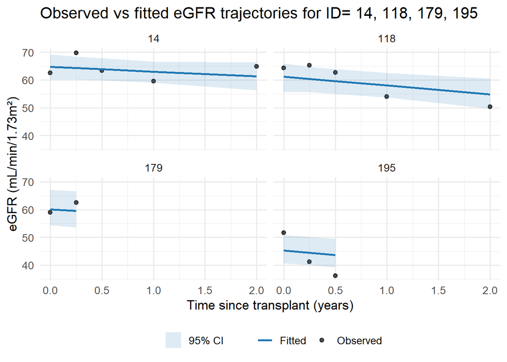

```r
library(dplyr)
library(ggplot2)
library(JMbayes2)

# pick 4 ids as examples
set.seed(123)
ids_example <- sample(unique(dat_long$id), 4)

# restrict to those patients
dat_long_sub <- dat_long %>%
  filter(id %in% ids_example) %>%
  mutate(status = 0L)

# get subject-specific fitted eGFR at the observed times
pred_long <- predict(
  jm_fit,
  newdata        = dat_long_sub,
  process        = "longitudinal",
  type           = "subject_specific",
  type_pred      = "response",
  control        = list(return_newdata = TRUE)
)

ggplot(pred_long, aes(x = time)) +
  geom_point(aes(y = egfr, colour = "Observed"), alpha = 0.7) +
  geom_line(aes(y = pred_egfr, colour = "Fitted"), linewidth = 1) +
  geom_ribbon(aes(ymin = low_egfr, ymax = upp_egfr, fill = "95% CI"),
              alpha = 0.15, colour = NA) +
  facet_wrap(~ id, ncol = 2) +
  scale_colour_manual(values = c("Observed" = "black",
                                 "Fitted"   = "#1f78b4")) +
  scale_fill_manual(values = c("95% CI" = "#1f78b4")) +
  labs(
    x = "Time since transplant (years)",
    y = "eGFR (mL/min/1.73m²)",
    colour = "",
    fill   = "",
    title  = "Observed vs fitted eGFR trajectories for ID= 14, 118, 179, 195"
  ) +
  theme_minimal(base_size = 13) +
  theme(legend.position = "bottom")
```

**Show R code**

```r
library(nlme)
library(survival)
library(JM)
```

**Show R code**

```r
library(animation)

# data
dat_long <- read.csv("https://raw.githubusercontent.com/NicoleDeLaMata/AdvancedSurvival/refs/heads/Data/egfr_joint_data.csv")          # long data with repeated eGFR
dat_surv <- read.csv("https://raw.githubusercontent.com/NicoleDeLaMata/AdvancedSurvival/refs/heads/Data/egfr_joint_baseline.csv")      # wide / baseline survival data

#Make sure factors are factors (important for JM)
dat_long$donor_type <- factor(dat_long$donor_type)
dat_surv$donor_type <- factor(dat_surv$donor_type, levels = levels(dat_long$donor_type))



# Fit longitudinal model (LME)
lmeFit <- lme(
  egfr ~ time + donor_type + recip_male + donor_age_c,
  random   = ~ time | id,
  data     = dat_long,
  na.action = na.omit,
  control  = lmeControl(opt = "optim")
)

#Fit survival model (Cox)
survFit <- coxph(
  Surv(time, status) ~ donor_type + recip_male + donor_age_c,
  data = dat_surv,
  x = TRUE
)

#Fit joint model (JM)
## method options include: "weibull-PH-aGH", "piecewise-PH-aGH", etc.
jointFit <- jointModel(
  lmeFit, survFit,
  timeVar = "time",
  method  = "piecewise-PH-aGH"
)

#Choose a patient ID
set.seed(1)
id_show <- sample(unique(dat_long$id), 1) #randomly select an ID

id_show<-118 # i selected the ID =118

dataP <- dat_long[dat_long$id == 14, ]
dataP <- dataP[order(dataP$time), ]
len_id <- nrow(dataP)

## A helper time grid for plotting survival curves
tmax <- max(dat_surv$time, na.rm = TRUE)


saveGIF({
  for (i in 1:len_id) {

    ## longitudinal history up to visit i
    newdat_i <- dataP[1:i, ]

    ## dynamic survival prediction conditional on history up to i
    sfit_i <- survfitJM(jointFit, newdata = newdat_i)

    ## ---- two-panel layout
    par(mfrow = c(1, 2), mar = c(4.5, 4.5, 3.5, 1))


    #Panel A: longitudinal data
    plot(
      x = newdat_i$time,
      y = newdat_i$egfr,
      pch = 16,
      xlim = range(dataP$time, na.rm = TRUE),
      ylim = range(dataP$egfr, na.rm = TRUE),
      xlab = "Time since transplant (years)",
      ylab = "eGFR (mL/min/1.73m²)",
      main = paste0("Longitudinal eGFR (ID = ", id_show, ")\nUp to visit ", i)
    )
    lines(newdat_i$time, newdat_i$egfr, lwd = 2)

    #(Optional) add subject-specific fitted mean from the LME
    tt <- seq(min(dataP$time), max(dataP$time), length.out = 100)
    pred_df <- data.frame(
      id = id_show,
      time = tt,
      donor_type  = newdat_i$donor_type[1],
      recip_male  = newdat_i$recip_male[1],
      donor_age_c = newdat_i$donor_age_c[1]
    )
    yhat <- predict(lmeFit, newdata = pred_df, level = 1)  # subject-specific
    lines(tt, yhat, lwd = 2, lty = 2)


    #Panel B: survival prediction
    plot(
      sfit_i,
      estimator = "mean",
      conf.int  = 0.95,
      fill.area = TRUE,
      col.area  = "lightblue",
      include.y = FALSE,
      xlim      = c(0, tmax),
      xlab      = "Time since transplant (years)",
      ylab      = "Predicted survival probability",
      main      = "Dynamic survival prediction"
    )
  }
}, ani.width = 900, ani.height = 420)
```

```
Output at: animation.gif
```

```
[1] TRUE
```

**Show R code**

```r
#for showing the gif file in the output no need to run
#dir.create("images", showWarnings = FALSE)
#file.rename("animation.gif", "images/animation.gif")
```

[figure not shown]